# Importation des librairies

```python
import numpy as np
import pandas as pd
import matplotlib.pyplot as plt
import seaborn as sns
import scipy as sc
from scipy.stats.stats import pearsonr
```

# Contexte et source des données

La collecte de ces données se fait suite à la propagation du Covid19 en Corée du Sud. Elle a été réaliséee en regroupant les informations du centre coréen de contrôle et de prévention des maladies et d'autres données accessibles concernant les personnes infectées. Le jeu de données se base en majorité sur la Corée du sub cependant on observe la présence de légère données concernant d'autres pays comme la France, le Canada, la Mongolie etc. Du fait de la négigeabilité de informations relatives aux autres pays que la Corée du sud, on considèrera en grande partie ces données comme coréennes. Cet ensemble est ainsi disponible sur GitHub via le lien utilisé ci-dessous.

```python
url = 'https://raw.githubusercontent.com/jihoo-kim/Data-Science-for-COVID-19/master/dataset/Patient/PatientInfo.csv'
data = pd.read_csv(url, error_bad_lines=False, sep=",")
```

```python
data.head()
```

|  | patient_id | global_num | sex | birth_year | age | country | province | city | disease | infection_case | infection_order | infected_by | contact_number | symptom_onset_date | confirmed_date | released_date | deceased_date | state |
| --- | --- | --- | --- | --- | --- | --- | --- | --- | --- | --- | --- | --- | --- | --- | --- | --- | --- | --- |
| 0 | 1000000001 | 2.0 | male | 1964.0 | 50s | Korea | Seoul | Gangseo-gu | NaN | overseas inflow | 1.0 | NaN | 75.0 | 2020-01-22 | 2020-01-23 | 2020-02-05 | NaN | released |
| 1 | 1000000002 | 5.0 | male | 1987.0 | 30s | Korea | Seoul | Jungnang-gu | NaN | overseas inflow | 1.0 | NaN | 31.0 | NaN | 2020-01-30 | 2020-03-02 | NaN | released |
| 2 | 1000000003 | 6.0 | male | 1964.0 | 50s | Korea | Seoul | Jongno-gu | NaN | contact with patient | 2.0 | 2.002000e+09 | 17.0 | NaN | 2020-01-30 | 2020-02-19 | NaN | released |
| 3 | 1000000004 | 7.0 | male | 1991.0 | 20s | Korea | Seoul | Mapo-gu | NaN | overseas inflow | 1.0 | NaN | 9.0 | 2020-01-26 | 2020-01-30 | 2020-02-15 | NaN | released |
| 4 | 1000000005 | 9.0 | female | 1992.0 | 20s | Korea | Seoul | Seongbuk-gu | NaN | contact with patient | 2.0 | 1.000000e+09 | 2.0 | NaN | 2020-01-31 | 2020-02-24 | NaN | released |

## Explication des variables :

- patient_id : ID du patient
- global_num : Numéro attribué à chaque patient (hormi ceux de Busan) par le centre coréen de contrôle et de prévention des maladies
- sex : Sexe du patient
- birth_year : Année de naissance du patient
- age : Tranche d'âge du patient (0s : 0-9 ans, 10s : 10-19 ans, 20s : 20-30 ans,..., 100s : 100-109 ans)
- country : Pays du patient
- province : Province d'origine du patient
- city : Ville du patient
- disease : Maladie du patient
- infection_case : Cause d'infection du patient
- infection_order : Ordre d'infection
- ifected_by : ID de la personne ayant contamné le patient
- contact_number : Nombre de personne avec qui le patient a été en contact
- symptom_onset_date : Date des symptômes
- confirmed_date : Date de confirmation des symptômes
- released_date : Date de sortie des patients guéris
- deceased_date : Date de décès des patients morts
- state : Etat de la personne (sortie, hospitalisée ou décédée)

# Valeurs manquantes

On calcule le taux de valeurs manquantes dans notre dataset. Cette information nous permettra par la suite d'avoir une idée précise des variables que nous allons devoir traiter plus particulièrement dans la suite.

```python
taux_manquant = (data.isna().sum()/data.shape[0]).sort_values()
print(taux_manquant)
```

```
patient_id            0.000000
province              0.000000
country               0.000000
state                 0.000000
confirmed_date        0.000885
sex                   0.022727
city                  0.023318
age                   0.024793
birth_year            0.136068
infection_case        0.226682
global_num            0.328217
released_date         0.608323
infected_by           0.757379
contact_number        0.810213
symptom_onset_date    0.858028
deceased_date         0.981700
infection_order       0.990850
disease               0.994687
dtype: float64
```

```
Text(0.5,1,u'R\xe9partition des valeurs manquantes')
```

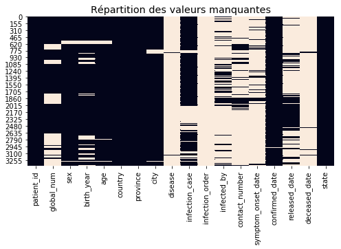

```python
plt.figure(figsize=(8,4))
sns.heatmap(data.isna(), cbar=False)
plt.title(u'Répartition des valeurs manquantes', size = 'x-large', )
```

### Explications :

On visualise notre dataset de façon à avoir la répartition de nos valeurs manquantes par variables. On remarque ainsi que les variables avec le plus de valeurs manquantes concernent la détection ou non d'une maladie, avec l'ordre d'infection qui y est associé. Les variables ayant entre 2% et 13% de données manquantes sont celles concernant l'identification de la personne (sexe, âge, ville). Entre 22% et 85%, on a les variables relatives à la cause de contamination par le Covid19.

La présence de traits noirs sur les autres colonnes nous indique premièrement la possibilité de faire des opérations de remplacement des valeurs manquantes (pour les variables quantitatives), ensuite cela nous montre la présence d'une corrélation entre elles.

# Exploration des données

A partir de cette étape, on s'intéresse un peu plus à notre variable cible 'state', qui donne les différents états possibles d'une personne (hospitalisée, sortie et décédée).

```
Text(0.5,1,u'R\xe9partition des \xe9tats de personnes')
```

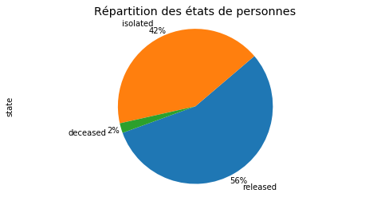

```python
plt.figure(figsize=(8,4))
data['state'].value_counts(normalize=True).plot.pie(autopct='%1.0f%%', pctdistance=1.1,
                                                    labeldistance=1.2, startangle=200)
plt.axis('equal')

plt.title(u'Répartition des états de personnes', size = 'x-large')
```

## Etude selon le sexe

Nous allons étudier la répartition des cas selon le sexe de l'individu, en prenant en compte la population comme étant l'effectif de note dataset.

```python
pd.crosstab(data['sex'], data['state'])
```

| state sex | deceased | isolated | released |
| --- | --- | --- | --- |
| female | 25 | 780 | 1051 |
| male | 44 | 595 | 816 |

### Répartition des femmes

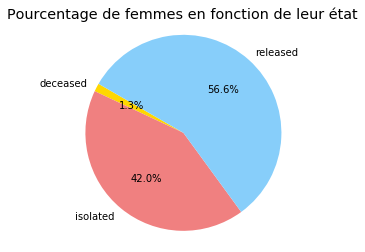

```python
labels = 'deceased', 'isolated', 'released'
sizes = [25, 780, 1051]
colors = ['gold', 'lightcoral', 'lightskyblue']

plt.pie(sizes, labels=labels, colors=colors,autopct='%1.1f%%', startangle=150)
plt.axis('equal')
plt.title(u'Pourcentage de femmes en fonction de leur état', size = 'x-large')
plt.show()
```

### Répartition des hommes

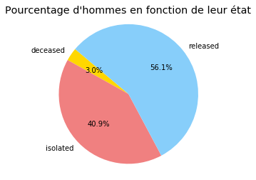

```python
labels = 'deceased', 'isolated', 'released'
sizes = [44, 595, 816]
colors = ['gold', 'lightcoral', 'lightskyblue']

plt.pie(sizes, labels=labels, colors=colors,autopct='%1.1f%%', startangle=140)
plt.axis('equal')
plt.title(u'Pourcentage d\'hommes en fonction de leur état', size = 'x-large')
plt.show()
```

#### Remarques :

Des graphiques ci-dessus, il en ressort que malgré les femmes coréennes réagissent mieux que les hommes puisque 56.6% d'entre elles sortent de l'hôpital contre 56.1% d'hommes. Cette différence est beaucoup plus observable concernant le nombre de mort où on a 1.3% de femmes décédées contre 3% d'hommes.

## Etude par tranches d'âge

Après avoir visualisé nos données selon le sexe, nous allons étudier la répartition des cas par tranche d'âge des individus.

```python
pd.crosstab(data['state'], data['age'])
```

| age state | 0s | 100s | 10s | 20s | 30s | 40s | 50s | 60s | 70s | 80s | 90s |
| --- | --- | --- | --- | --- | --- | --- | --- | --- | --- | --- | --- |
| deceased | 0 | 0 | 0 | 0 | 1 | 2 | 7 | 11 | 19 | 22 | 7 |
| isolated | 29 | 1 | 63 | 293 | 175 | 164 | 237 | 195 | 109 | 85 | 26 |
| released | 26 | 0 | 87 | 509 | 262 | 289 | 353 | 195 | 76 | 49 | 12 |

### Tranche 20-40 ans

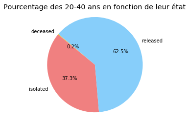

```python
labels = 'deceased', 'isolated', 'released'
sizes = [3, 632, 1060]
colors = ['gold', 'lightcoral', 'lightskyblue']

plt.pie(sizes, labels=labels, colors=colors,autopct='%1.1f%%', startangle=140)
plt.axis('equal')
plt.title(u'Pourcentage des 20-40 ans en fonction de leur état', size = 'x-large')
plt.show()
```

### Tranche 50-90 ans

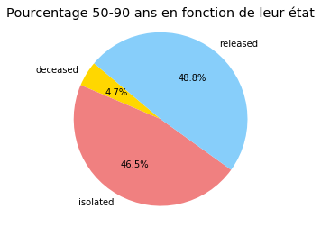

```python
labels = 'deceased', 'isolated', 'released'
sizes = [66, 652, 685]
colors = ['gold', 'lightcoral', 'lightskyblue']

plt.pie(sizes, labels=labels, colors=colors,autopct='%1.1f%%', startangle=140)
plt.axis('equal')
plt.title(u'Pourcentage 50-90 ans en fonction de leur état', size = 'x-large')
plt.show()
```

#### Remarques :

On remarque ainsi que parmi les personnes de 20 à 40 ans, seule une minorité décède du Covid19 quand jusqu'à 62.5% d'entre eux survivent.

Concernant les personnes de 50 à 90 ans on constate un nombre de décès plus important, cependant cela ne reste pas comparable en terme de chiffre au précédent cas puisque l'effectif total n'est pas le même.

Néanmoins on observe là encore que parmi cet effectif plus restreint, une majorité de personne survivent à l'infection. Ce manque d'effectif peut être expliqué par le fait que les personnes agées sont en maisons de retraites pour la plupart et donc non enregistrées dans ce jeu de données prenant en compte les hôpitaux et centres de santés.

## Répartition globale

Grâce aux graphiques ci-dessous, on avons une vision plus générale des cas en fonction de la tranche d'âge et du sexe de l'individu. Cela nous permet de croiser ces informations afin d'en tirer des conclusions plus visibles.

```
Text(0.5,1,u"R\xe9partition des cas selon la tranche d'\xe2ge")
```

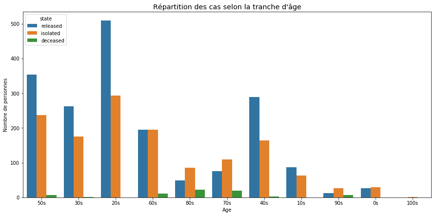

```python
plt.figure(figsize=(15,7))
sns.countplot(x='age', hue='state', data=data)
plt.xlabel('Age')
plt.ylabel('Nombre de personnes')
plt.title(u'Répartition des cas selon la tranche d\'âge', size = 'x-large')
```

```
Text(0.5,1,u'R\xe9partition des cas selon le sexe')
```

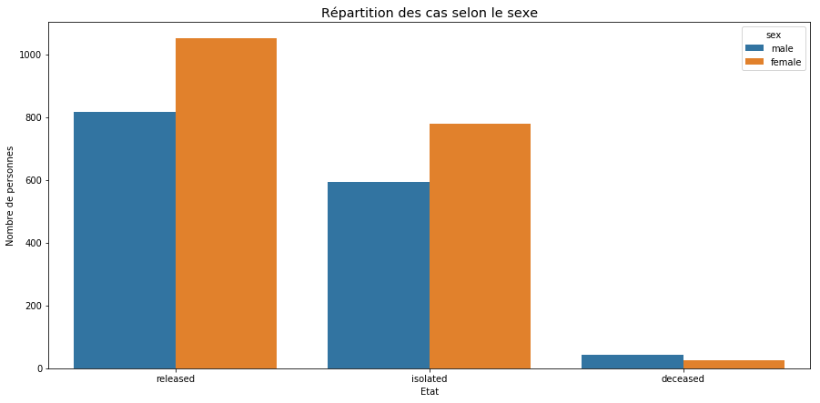

```python
plt.figure(figsize=(15,7))
sns.countplot(x='state', hue='sex', data=data)
plt.xlabel('Etat')
plt.ylabel('Nombre de personnes')
plt.title(u'Répartition des cas selon le sexe', size = 'x-large')
```

#### Remarques :

Grâce aux deux graphiques ci-dessus, on visualise les conclusions déjà effectuées précédemment. Il en ressort ainsi que sur la population de notre dataset, les 20-50 ans sont parmi les plus infectés par le virus, néanmois ce sont les 60-89 ans qui en décèdent le plus. De manière générale, les hommes décèdent plus du Covid19 lorsque les femmes s'en sortent mieux.

## Etude par rapport à la cause de l'infection

```python
pd.crosstab(data['infection_case'], data['state'])
```

| state infection_case | deceased | isolated | released |
| --- | --- | --- | --- |
| Bonghwa Pureun Nursing Home | 1 | 30 | 0 |
| Changnyeong Coin Karaoke | 0 | 0 | 4 |
| Cheongdo Daenam Hospital | 7 | 13 | 1 |
| Dongan Church | 0 | 4 | 13 |
| Eunpyeong St. Mary's Hospital | 0 | 1 | 15 |
| Geochang Church | 0 | 0 | 6 |
| Guro-gu Call Center | 1 | 16 | 95 |
| Gyeongsan Cham Joeun Community Center | 0 | 2 | 8 |
| Gyeongsan Jeil Silver Town | 1 | 2 | 9 |
| Gyeongsan Seorin Nursing Home | 0 | 7 | 8 |
| Milal Shelter | 0 | 1 | 10 |
| Ministry of Oceans and Fisheries | 0 | 3 | 25 |
| Onchun Church | 0 | 0 | 33 |
| Pilgrimage to Israel | 0 | 0 | 2 |
| River of Grace Community Church | 0 | 0 | 1 |
| Seongdong-gu APT | 0 | 3 | 10 |
| Shincheonji Church | 2 | 25 | 80 |
| Suyeong-gu Kindergarten | 0 | 0 | 3 |
| contact with patient | 4 | 566 | 398 |
| etc | 13 | 222 | 337 |
| gym facility in Cheonan | 0 | 2 | 28 |
| gym facility in Sejong | 0 | 0 | 4 |
| overseas inflow | 0 | 366 | 238 |

## Visualisation des causes

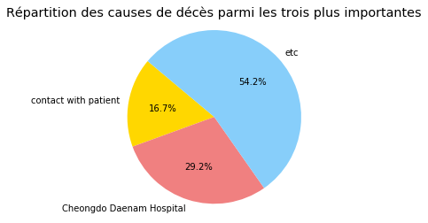

```python
labels = 'contact with patient', 'Cheongdo Daenam Hospital', 'etc'
sizes = [4, 7, 13]
colors = ['gold', 'lightcoral', 'lightskyblue']

plt.pie(sizes, labels=labels, colors=colors,autopct='%1.1f%%', startangle=140)
plt.axis('equal')
plt.title(u'Répartition des causes de décès parmi les trois plus importantes', size = 'x-large')
plt.show()
```

# Conclusion

L'analyse statistique de notre jeu de données a fait ressortir le fait que parmi les hommes touchés par le Covid19, jusqu'à 3% d'entre eux en décédaient alors que seulement 1.3% de femmes mouraient de l'infection. On a aussi vu que les 20-40 ans sont plus touchés par l'infection que les 50-90 ans, toute fois ils s'en sortent mieux puisque 0.2% d'entre eux meurent quand 4.7% des 50-90 ans décèdent de l'infection.

# Variables importantes

Comme nous l'avons vu grâce aux études statistiques, l'âge et le sexe jouent un rôle dans la survie face à l'infection. Dans la suite de notre travail et notamment dans la partir prédiction, nous verrons l'importance des autres variables dans la survie ou non d'une personne infectée.

# Finalisation de l'étude

```python
data = data.drop(columns=['patient_id','global_num','birth_year','disease','infection_order','infected_by','released_date','deceased_date','symptom_onset_date','contact_number'])
```

## Explication du choix des variables à garder pour la suite

Pour la suite de notre étude on garde les variables ayant le moins de valeurs manquantes, mais aussi celles relatives à la nationalité, à la province d'infection et la ville où la personne a été prise en charge. La date de confirmation des symptome est aussi une variable intéressante qui va nous aider à regrouper les périodes où on dénombre le plus de décès. Nous avons aussi fait le choix de ne garder que les tranches d'âges des personnes afin d'avoir des résultats plus globaux.

Du fait de la quantité de valeur manquantes trop élévée de la variable 'contact_number', nous n'allons pas garder cette information pour la suite, néanmoins on peut poser l'hypothèse qu'elle joue aussi un rôle dans la survie ou non à l'épidémie.

```python
data.head()
```

|  | sex | age | country | province | city | infection_case | confirmed_date | state |
| --- | --- | --- | --- | --- | --- | --- | --- | --- |
| 0 | male | 50s | Korea | Seoul | Gangseo-gu | overseas inflow | 2020-01-23 | released |
| 1 | male | 30s | Korea | Seoul | Jungnang-gu | overseas inflow | 2020-01-30 | released |
| 2 | male | 50s | Korea | Seoul | Jongno-gu | contact with patient | 2020-01-30 | released |
| 3 | male | 20s | Korea | Seoul | Mapo-gu | overseas inflow | 2020-01-30 | released |
| 4 | female | 20s | Korea | Seoul | Seongbuk-gu | contact with patient | 2020-01-31 | released |

# Sauvegarde dans un fichier

```python
data.to_csv("dead_survie.csv",sep = ";",encoding="utf-8", index=False)
```

#### Auteurs :

Rédigé par Daniel ATANGANA, avec la participation de :

- BUISSON-CHAVOT Julien
- CHATRY Roxane
- GORRICHON Nahia
- VIRGAUX Pierre

#### Contexte : Etude statistique sur le Covid19

#### Date : 27/05/2020